# Lecture 10.2 More decision trees

EBA3501 Foundations of Data Science

Jan Ditzen

2026-11-03

## Outline

1. Handling ordinal-categorical data,
2. Classification trees,
3. Measuring feature importance.

## Categorical data

> [This data set](https://islp.readthedocs.io/en/latest/datasets/Bikeshare.html) contains the hourly and daily count of rental bikes between years 2011 and 2012 in Capital bikeshare system, along with weather and seasonal information.

```python
from ISLP import load_data
bikeshare = load_data('Bikeshare')
bikeshare.head()
```

|  | season | mnth | day | hr | holiday | weekday | workingday | weathersit | temp | atemp | hum | windspeed | casual | registered | bikers |
| --- | --- | --- | --- | --- | --- | --- | --- | --- | --- | --- | --- | --- | --- | --- | --- |
| 0 | 1 | Jan | 1 | 0 | 0 | 6 | 0 | clear | 0.24 | 0.2879 | 0.81 | 0.0 | 3 | 13 | 16 |
| 1 | 1 | Jan | 1 | 1 | 0 | 6 | 0 | clear | 0.22 | 0.2727 | 0.80 | 0.0 | 8 | 32 | 40 |
| 2 | 1 | Jan | 1 | 2 | 0 | 6 | 0 | clear | 0.22 | 0.2727 | 0.80 | 0.0 | 5 | 27 | 32 |
| 3 | 1 | Jan | 1 | 3 | 0 | 6 | 0 | clear | 0.24 | 0.2879 | 0.75 | 0.0 | 3 | 10 | 13 |
| 4 | 1 | Jan | 1 | 4 | 0 | 6 | 0 | clear | 0.24 | 0.2879 | 0.75 | 0.0 | 0 | 1 | 1 |

We define our features and targets.

```python
X = bikeshare.drop(["bikers", "casual", "registered", "season"], axis=1)
y = bikeshare["bikers"]
```

## Decision tree

Can we fit a regression tree to this data?

- Problem?
- Solution

```python
from sklearn.tree import DecisionTreeRegressor
reg = DecisionTreeRegressor(random_state=0, max_depth = 5).fit(X,y)
reg
```

[output not shown]

[output cut: 25 more lines]

[output not shown]

The problem lies with the categorical features:

```python
X.head()
```

|  | mnth | day | hr | holiday | weekday | workingday | weathersit | temp | atemp | hum | windspeed |
| --- | --- | --- | --- | --- | --- | --- | --- | --- | --- | --- | --- |
| 0 | Jan | 1 | 0 | 0 | 6 | 0 | clear | 0.24 | 0.2879 | 0.81 | 0.0 |
| 1 | Jan | 1 | 1 | 0 | 6 | 0 | clear | 0.22 | 0.2727 | 0.80 | 0.0 |
| 2 | Jan | 1 | 2 | 0 | 6 | 0 | clear | 0.22 | 0.2727 | 0.80 | 0.0 |
| 3 | Jan | 1 | 3 | 0 | 6 | 0 | clear | 0.24 | 0.2879 | 0.75 | 0.0 |
| 4 | Jan | 1 | 4 | 0 | 6 | 0 | clear | 0.24 | 0.2879 | 0.75 | 0.0 |

Is one-hot encoding a good idea here? Probably not, because decision trees are so incredibly flexible, and we increase the size of our feature space by `11` if we make months one-hot encoded!

## `OrdinalEncoder`

Something is “ordinal” if its levels have a meaningful order, such as rankings. Calendar months are cyclic rather than ordinal, so a numeric month encoding imposes an imperfect ordering.

- Likert scales
- Alternative
- Months
- Your own order
- `weathersit`

> How much do you agree with the following statement: “I am the life of the party.”

| Strongly disagree | Disagree | Neutral | Agree | Stongly Agree |
| --- | --- | --- | --- | --- |
| 0 | 1 | 2 | 3 | 4 |

The answers have been translated to number using a *linear ordinal encoding*.

The lowest number doesn’t matter, and the spacing doesn’t matter - as long as it’s the same spacing between all items, the coding is linear.

| Strongly disagree | Disagree | Neutral | Agree | Stongly Agree |
| --- | --- | --- | --- | --- |
| -27 | -4 | 19 | 42 | 65 |

Let’s encode the months using the `OrdinalEncoder`. This is a *transformer*.

```python
from sklearn.preprocessing import OrdinalEncoder

obj = OrdinalEncoder()
obj.fit_transform(X[["mnth"]])
```

```
array([[4.],
       [4.],
       [4.],
       ...,
       [2.],
       [2.],
       [2.]], shape=(8645, 1))
```

Now we must inspect the categories:

```python
obj.categories_
```

```
[array(['April', 'Aug', 'Dec', 'Feb', 'Jan', 'July', 'June', 'March',
        'May', 'Nov', 'Oct', 'Sept'], dtype=object)]
```

The categories are in the *wrong order*. As it turns out, `sklearn` automatically sorts the categories for you.

The correct order can easily be found from the data:

```python
categories = X["mnth"].unique().tolist()
print(*categories)
```

```
Jan Feb March April May June July Aug Sept Oct Nov Dec
```

Now supply the categories to the `OrdinalEncoder`:

```python
obj = OrdinalEncoder(categories = [categories]).fit(X[["mnth"]])
```

And the fit_transform looks like this.

```python
obj.fit_transform(X[["mnth"]])
```

```
array([[ 0.],
       [ 0.],
       [ 0.],
       ...,
       [11.],
       [11.],
       [11.]], shape=(8645, 1))
```

- The other categorical variable is `weathersit`.
- The order from `unique` looks reasonable.

```python
X["weathersit"].unique().tolist()
```

```
['clear', 'cloudy/misty', 'light rain/snow', 'heavy rain/snow']
```

## Pipeline

We use `ColumnTransformer` to the the ordinal encoding.

```python
from sklearn.compose import ColumnTransformer
mnth = [X["mnth"].unique().tolist()]
weathersit = [X["weathersit"].unique().tolist()]

columns = ColumnTransformer([
    ("mnth", OrdinalEncoder(categories = mnth), ["mnth"]),
    ("weathersit", OrdinalEncoder(categories = weathersit), ["weathersit"])
  ],remainder = "passthrough")
```

And place it into a pipeline.

```python
from sklearn.tree import DecisionTreeRegressor
from sklearn.pipeline import Pipeline

tree_pipe = Pipeline([
  ("cols", columns),
  ("tree", DecisionTreeRegressor(random_state=0))
])
```

## Fitting

```python
tree_pipe.fit(X, y)
```

Cross-validate to find the score.

```python
from sklearn.model_selection import cross_val_score
cross_val_score(tree_pipe, X, y, cv = 10).mean()
```

```
np.float64(0.6671295786268264)
```

## Can we improve the model?

1. Change parameters?
2. Add pruning.
3. Cross-validate the pruning parameter. **The most important.**
4. Use `SequentialFeatureSelector`?

## Cross-validated pruning

Use `GridSearchCV` - as always!

```python
from sklearn.model_selection import GridSearchCV
ccp_alphas = np.logspace(-2, 1, 20)
grid = GridSearchCV(tree_pipe, param_grid={"tree__ccp_alpha": ccp_alphas}, cv=10)
grid.fit(X, y)
pass
```

```python
grid.best_score_
```

```
np.float64(0.6998202281581647)
```

```python
grid.best_params_
```

```
{'tree__ccp_alpha': np.float64(1.1288378916846884)}
```

## Feature selection

Recall `SequentialFeatureSelector`. It finds the best features according the a specified model, and returns an array containing those best features.

- `select`
- `pipe`
- `fit`
- `score`

We define a selector using our desired model first.

```python
from sklearn.feature_selection import SequentialFeatureSelector

select = SequentialFeatureSelector(
    DecisionTreeRegressor(random_state=0), n_features_to_select=7, direction="backward"
)
```

- Now we have a pipeline - notice the order.
- We have all data transformations *before* the feature selection step.
- And the regression model is *equal* to the regression model in the selection step.

```python
pipe = Pipeline(
    [
        ("cols", columns),
        ("select", select),
        ("tree", DecisionTreeRegressor(random_state=0)),
    ]
)
```

[output not shown]

```python
cross_val_score(pipe, X, y, cv = 10).mean()
```

```
np.float64(0.5674692981953152)
```

# Classification trees

## Classification trees - Fundamental idea of decision trees

1. We divide the predictor space — that is, the set of possible values for $X_1,X_2,...,X_p$ — into $J$ distinct and non-overlapping rectangles, $R_1,R_2,...,R_J$.
2. For every observation that falls into the rectangle $R_j$ its predicted value is equal to the *most frequent* value in $R_j$.
3. The *predicted probability* of belonging to class $i$ is the proportion of observations in the leaf that belong to class $i$.

The goal is to find the rectangles $R_1,...,R_J$ that minimize the weighted Gini score,
$$\sum_{m=1}^{J} n_m\left(1-\sum_{i=1}^{C}\hat{p}_{mi}^{2}\right),$$

where $n_m$ is the number of observations in $R_m$ and $\hat{p}_{mi}$ is the proportion of its training observations that belong to class $i$.

## Data

- We use the `iris` data set.
- **Targets:** Three species of flowers.
- **Features:** Four physical measurements.

```python
from sklearn import datasets

X, y = datasets.load_iris(as_frame = True, return_X_y = True)
X.head()
```

|  | sepal length (cm) | sepal width (cm) | petal length (cm) | petal width (cm) |
| --- | --- | --- | --- | --- |
| 0 | 5.1 | 3.5 | 1.4 | 0.2 |
| 1 | 4.9 | 3.0 | 1.4 | 0.2 |
| 2 | 4.7 | 3.2 | 1.3 | 0.2 |
| 3 | 4.6 | 3.1 | 1.5 | 0.2 |
| 4 | 5.0 | 3.6 | 1.4 | 0.2 |

## Fitting a model

We fit a model,

```python
from sklearn.tree import DecisionTreeClassifier
tree = DecisionTreeClassifier(random_state=0, max_depth = 5).fit(X,y)
```

and inspect the score:

```python
cross_val_score(tree, X, y, cv = 10).mean()
```

```
np.float64(0.96)
```

Wow!

## Gini and entropy

- In regression trees the quality of a split was measured by reduction in *mean squared error*.
- That is not suitable for classification, especially with multiple classes!
- We may use the *entropy* (log loss) or *gini* criteria.

$$Gini(p) = 1 - \sum_{i=1}^{K} p_i^2.$$

Hence Gini is minimized with perfect prediction, just as the log score / entropy.

## Testing both

Define an “entropy” tree,

```python
tree_entropy = DecisionTreeClassifier(criterion = "entropy", max_depth = 5)
```

and inspect the score:

```python
[cross_val_score(tree_entropy, X, y, cv = 10).mean(), cross_val_score(tree, X, y, cv = 10).mean()]
```

```
[np.float64(0.9533333333333334), np.float64(0.96)]
```

- There’s very little difference between these two.
- Gini is the default criterion, is probably the most popular, and is OK to use.
- Gini bears no relationship to the Gini coefficient for measuring inequality.

## Classification trees vs regression trees

- There is, conceptually speaking, almost no difference between regression trees and classification trees.
- The only difference is the choice of “impurity” index, which is typically mean squared error for regression trees and the Gini impurity for classification trees.

## How do you improve the model?

- Trees can be improved by changing the `max_depth` parameters, by doing feature selection, and so forth.
- But the *most important part* is to cross-validate the tuning parameter!

```python
from sklearn.model_selection import GridSearchCV
ccp_alphas = np.logspace(-2, 1, 20)
grid_iris = GridSearchCV(tree, param_grid={"ccp_alpha": ccp_alphas})
pass
```

```python
grid_iris.fit(X, y)
```

```
GridSearchCV(estimator=DecisionTreeClassifier(max_depth=5, random_state=0),
             param_grid={'ccp_alpha': array([ 0.01      ,  0.0143845 ,  0.02069138,  0.02976351,  0.04281332,
        0.06158482,  0.08858668,  0.1274275 ,  0.18329807,  0.26366509,
        0.37926902,  0.54555948,  0.78475997,  1.12883789,  1.62377674,
        2.33572147,  3.35981829,  4.83293024,  6.95192796, 10.        ])})
```

```python
grid_iris.best_params_
```

```
{'ccp_alpha': np.float64(0.01438449888287663)}
```

```python
grid_iris.best_score_
```

```
np.float64(0.9666666666666668)
```

# Feature importance

## Hitters data

We’ll use the `hitters` data once again.

- Data
- Model

```python
from ISLP import load_data
```

```python
Hitters = load_data("Hitters")
Hitters = Hitters.dropna()
Hitters.head()
```

|  | AtBat | Hits | HmRun | Runs | RBI | Walks | Years | CAtBat | CHits | CHmRun | CRuns | CRBI | CWalks | League | Division | PutOuts | Assists | Errors | Salary | NewLeague |
| --- | --- | --- | --- | --- | --- | --- | --- | --- | --- | --- | --- | --- | --- | --- | --- | --- | --- | --- | --- | --- |
| 1 | 315 | 81 | 7 | 24 | 38 | 39 | 14 | 3449 | 835 | 69 | 321 | 414 | 375 | N | W | 632 | 43 | 10 | 475.0 | N |
| 2 | 479 | 130 | 18 | 66 | 72 | 76 | 3 | 1624 | 457 | 63 | 224 | 266 | 263 | A | W | 880 | 82 | 14 | 480.0 | A |
| 3 | 496 | 141 | 20 | 65 | 78 | 37 | 11 | 5628 | 1575 | 225 | 828 | 838 | 354 | N | E | 200 | 11 | 3 | 500.0 | N |
| 4 | 321 | 87 | 10 | 39 | 42 | 30 | 2 | 396 | 101 | 12 | 48 | 46 | 33 | N | E | 805 | 40 | 4 | 91.5 | N |
| 5 | 594 | 169 | 4 | 74 | 51 | 35 | 11 | 4408 | 1133 | 19 | 501 | 336 | 194 | A | W | 282 | 421 | 25 | 750.0 | A |

```python
from sklearn.tree import DecisionTreeRegressor

X = Hitters.drop(["Salary", "League", "Division", "NewLeague"], axis=1)
y = Hitters["Salary"]
regressor = DecisionTreeRegressor(random_state=0).fit(X, y)
```

## Kinds of importance measurements

1. **Gini importance.**
- Measures how much a feature increases model performance on the training data.
2. **Permutation importance.**
- Randomly shuffles values of a single feature, then measure the reduction in model performance.
- The greater the reduction, the more important the feature is.
- Uses *test* data.
- Recommended over Gini importance, but both work decently well.

## Gini importance

- Importance
- Plotting importance

```python
feature_importance = regressor.feature_importances_
feature_importance
```

```
array([0.03785205, 0.02748689, 0.00719915, 0.008188  , 0.09054035,
       0.21966727, 0.00740933, 0.03683291, 0.40406401, 0.01079445,
       0.00390843, 0.04597192, 0.0090425 , 0.04888972, 0.01183943,
       0.0303136 ])
```

You may use the code below to plot feature importances.

**Plotting feature importance**

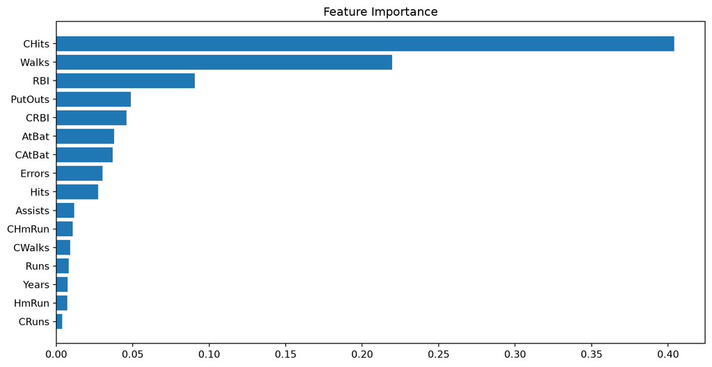

```python
feature_importance = regressor.feature_importances_
sorted_idx = np.argsort(feature_importance)
fig = plt.figure(figsize=(12, 6))
plt.barh(range(len(sorted_idx)), feature_importance[sorted_idx], align="center")
plt.yticks(range(len(sorted_idx)), np.array(X.columns)[sorted_idx])
plt.title("Feature Importance")
pass
```

Hence `CHits` and `Walks`, for instance, are very important.

## Permutation importance

- Importances
- Plot
- With error bars

```python
from sklearn.inspection import permutation_importance

perm = permutation_importance(regressor, X, y)
perm
```

```
{'importances_mean': array([0.1633276 , 0.11489017, 0.02157102, 0.0382095 , 0.2883239 ,
        0.52845686, 0.06806575, 0.09273932, 0.73071055, 0.04471443,
        0.00964198, 0.42401509, 0.03875358, 0.13974417, 0.02476447,
        0.31460011]),
 'importances_std': array([0.01180959, 0.00956285, 0.0068831 , 0.00439694, 0.03186808,
        0.05059819, 0.00142684, 0.01413204, 0.06350299, 0.0074192 ,
        0.00314879, 0.02528938, 0.00625925, 0.05723258, 0.00449467,
        0.15399398]),
 'importances': array([[0.17213593, 0.17761528, 0.15359474, 0.14588516, 0.16740689],
        [0.12610448, 0.12094789, 0.1143078 , 0.09773705, 0.11535363],
        [0.01820091, 0.03533684, 0.01817184, 0.01807253, 0.01807299],
        [0.03533793, 0.04228523, 0.04436917, 0.03268999, 0.03636519],
        [0.31306528, 0.31892454, 0.24001208, 0.26061589, 0.30900169],
        [0.47745991, 0.5675041 , 0.45854182, 0.58416213, 0.55461634],
        [0.06763968, 0.06983383, 0.0690134 , 0.06562625, 0.0682156 ],
        [0.09250109, 0.11234454, 0.10430724, 0.07823354, 0.07631017],
        [0.83587067, 0.76779528, 0.69490595, 0.65771056, 0.69727026],
        [0.03783541, 0.0579959 , 0.03861212, 0.04723092, 0.04189779],
        [0.00590038, 0.00620452, 0.01044568, 0.0116485 , 0.01401081],
        [0.41365331, 0.43455544, 0.39782726, 0.46828675, 0.40575269],
        [0.05056245, 0.03608836, 0.03670611, 0.0383652 , 0.03204576],
        [0.03967676, 0.16836958, 0.12602618, 0.21174052, 0.15290783],
        [0.03127249, 0.01861022, 0.02647777, 0.02653354, 0.02092831],
        [0.42690161, 0.07770834, 0.4242236 , 0.4594008 , 0.1847662 ]])}
```

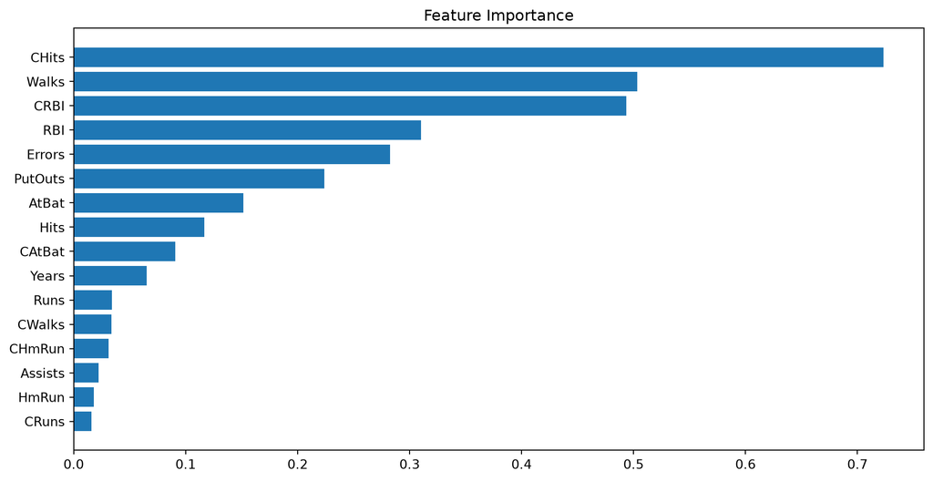

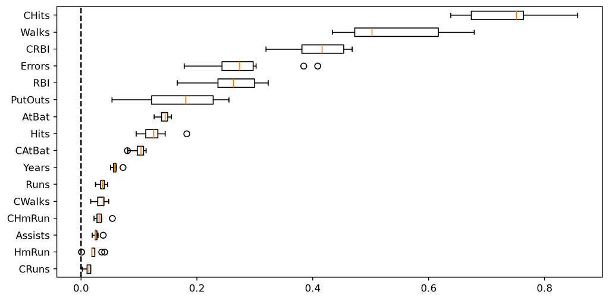

## Nota bene

- Features that of low importance for a bad model could be important for a good model.
- Important to evaluate the predictive power of your models using a cross-validation.
- Permutation importance does not reflect to the intrinsic predictive value of a feature by itself but how important this feature is for a particular model.

## Summary

1. `OrdinalEncoder` transforms ordinal data into numbers, and is frequently used even for categorical-ish data. Think about the bias-variance trade-off here!
2. Classification trees are similar to regression trees, but use the unfamiliar Gini impurity index.
3. There are several ways to measure feature importance; such plots are standard.